# Modeling regimes with extremes: the bayesdfa package for identifying and forecasting common trends and anomalies in multivariate time-series data

Eric J. Ward

Conservation Biology Division, Northwest Fisheries Science Center, National Marine Fisheries Service, National Oceanic and Atmospheric Administration

Sean C. Anderson

Pacific Biological Station, Fisheries and Oceans Canada

Luis A. Damiano

Iowa State University

Mary E. Hunsicker

Fish Ecology Division, Northwest Fisheries Science Center, National Marine Fisheries Service, National Oceanic and Atmospheric Administration

Michael A. Litzow

University Alaska Fairbanks, College of Fisheries and Ocean Sciences,

2019-07-30

Abstract

The *bayesdfa* package provides a flexible Bayesian modeling framework for applying dynamic factor analysis (DFA) to multivariate time-series data as a dimension reduction tool. The core estimation is done with the Stan probabilistic programming language. In addition to being one of the few Bayesian implementations of DFA, novel features of this model include (1) optionally modeling latent process deviations as drawn from a Student-t distribution to better model extremes, and (2) optionally including autoregressive and moving-average components in the latent trends. Besides estimation, we provide a series of plotting functions to visualize trends, loadings, and model predicted values. A secondary analysis for some applications is to identify regimes in latent trends. We provide a flexible Bayesian implementation of a Hidden Markov Model — also written with Stan — to characterize regime shifts in latent processes. We provide simulation testing and details on parameter sensitivities in supplementary information.

# Overview

A goal of many multivariate statistical techniques is to reduce dimensionality in observed data to identify shared or latent processes. Factor analysis models represent a general class of models used to relate multiple observations to a lower dimension (factors), while also considering different covariance structures of the observed data. Factors are not directly observed, but represent a hidden, shared process among variables. Though goals of factor analysis are sometimes similar to techniques such as principal component analysis (PCA), factor analysis models explicitly estimate residual error terms, whereas PCA does not (T. W. Anderson and Rubin 1956; Jolliffe 1986). These factor models are written as ${ y }_{ i }={ u }_{ i }+\textbf{ Z }{f}_{ i }+{ \varepsilon }_{ i }$, where observed data ${ y }_{ i }$ is a linear combination of an intercept ${ u }_{ i }$ and the product of latent factors ${f}_{ i }$ and loadings $\textbf{ Z }$ (loadings are sometimes referred to in the literature as $\textbf{L}$).

In a time-series setting, factor models may be extended to dynamic factor analysis (DFA) models. DFA models aim to reduce the dimensionality of a collection of time series by estimating a set of shared trends and factors, representing the linear effects of each trend on the observed data (Molenaar 1985; Zuur et al. 2003; Stock and Watson 2005). The number of trends $m$ is chosen to be less or equal than the number of time series $n$. The general form of the DFA model can be formulated as a state-space model (Petris 2010). The latent processes (also referred to as ‘trends’) are generally modeled as random walks, so that trend $i$ is modeled as ${ x }_{ i,t+1 }={ x }_{ i,t }+{ w }_{ i,t }$ where ${ x }_{ i, t }$ is the value of the $i$-th latent trend at time $t$, and the deviations ${ w }_{ i,t }$ are modeled as white noise. Across trends, these deviations are modeled as $\textbf{w}_{t} \sim \mathrm{MVN}(0, \textbf{Q})$. The latent trends ${ x }_{ i,t }$ are linked to data via a loadings matrix $\textbf{Z}$ whose values do not evolve through time, ${ y }_{ t }=\textbf{Z}{ x }_{ t } + \textbf{a} + \textbf{B}{ d }_{ t } + \textbf{e}_{t}$. The loadings matrix $\textbf{Z}$ is dimensioned $n\: \times\: m$ so that ${Z}_{j,i}$ represents the effect of trend $i$ on time series $j$. The parameters $\textbf{a}$ and $\textbf{B}$ are optional parameters, representing time-series-specific intercepts and effects of covariates, ${d}_{t}$. Finally, the residual errors are assumed to be $\textbf{e}_{t} \sim \mathrm{MVN}(0,\textbf{R})$, where $\textbf{R}$ is an estimated covariance matrix.

Estimation of DFA models is typically done in a maximum likelihood framework, using the expectation-maximization (EM) algorithm or other optimization tools. Implementation of these methods is available in multiple R packages including [*dlm*](https://CRAN.R-project.org/package=dlm) (Petris 2010), [*KFAS*](https://CRAN.R-project.org/package=KFAS) (Helske 2017), [*MARSS*](https://CRAN.R-project.org/package=MARSS) (Holmes, Ward, and Wills 2012), and [*tsfa*](https://CRAN.R-project.org/package=tsfa) (Gilbert and Meijer 2005). Challenges in parameter estimation and interpretation for DFA models have been well studied. Without constraints, parameters in the DFA model are not identifiable (Harvey 1990; Zuur et al. 2003). To ensure identifiability of variance parameters, for example, the covariance matrix $\textbf{Q}$ is generally fixed as an identity matrix (Harvey 1990). To avoid confounding the latent trends and loadings matrix $\textbf{Z}$, elements of $\textbf{Z}$ must also be constrained. A common choice of constraints is for the elements in the first $m-1$ rows of $\textbf{Z}$ to be set to zero if the column index is greater than the row index, $j > i$ (Harvey 1990), though other constraints have been proposed (Bai and Wang 2015). For a 3-trend DFA model for instance, these constraints would mean that the $\textbf{Z}$ matrix parameters would be configured as
$$\begin{matrix}
\begin{bmatrix} { Z }_{ 1,1 } & 0 & 0 \\ { Z }_{ 2,1 } & { Z
}_{ 2,2 } & 0 \\ { Z }_{ 3,1 } & { Z }_{ 3,2 } & { Z }_{ 3,3
} \\ ... & ... & ... \end{bmatrix} \end{matrix}.$$

Several previous approaches to DFA estimation in a maximum likelihood framework also center (subtract the sample means) or standardize (subtract the sample means and divide by the sample standard deviations) data prior to fitting DFA models and set the intercepts $a$ equal to zero to avoid potential confounding of level parameters (Holmes, Ward, and Scheuerell 2012). We adopt a similar approach, allowing users to either center or standardize data before estimation, and not including the intercepts as estimated parameters.

## Label switching

We developed our DFA model in a Bayesian framework, using Stan and the package [*rstan*](https://CRAN.R-project.org/package=rstan) (Stan Development Team 2016), which implements Markov chain Monte Carlo (MCMC) using the No-U Turn Sampling (NUTS) algorithm (Hoffman and Gelman 2014; Carpenter et al. 2017). Although estimation of the DFA model in a Bayesian setting is not new (Aguilar and West 2000; Koop and Korobilis 2010; Stock and Watson 2011), it presents several interesting challenges over the EM algorithm. In addition to the constraints on $\textbf{Q}$ and $\textbf{Z}$, Bayesian estimation suffers from a problem of label switching. In particular, elements of $\textbf{F}$ or $\textbf{Z}$ may flip sign within an MCMC chain, or multiple chains may converge on parameters that are identical in magnitude but with different signs.

To minimize issues with label switching, previous work on Bayesian factor analysis has proposed additional constraints on the loadings matrix, including setting the elements of $\textbf{Z}$ to be constrained (-1, 1), or adding a positive constraint to the diagonal, ${ Z }_{ ii }>0$ (Aguilar and West 2000; Geweke and Zhou 1996). Though these constraints generally help, there may be situations where MCMC chains still do not converge. To address this issue, we adopt the parameter-expanded priors for the loadings and trends proposed by Ghosh and Dunson (2009). To ensure that the sign of the estimated quantities is the same across MCMC chains, we created the function `flip_trends()` to flip the posterior samples of MCMC chains relative to the first chain as needed.

# The Bayesian dynamic factor model with extremes

## Including autoregressive and moving average components

The trends of the dynamic factor model are most commonly modeled as non-stationary random walks, ${ x }_{ i,t+1 }={ x }_{ i,t }+{ w }_{ i,t }$, where the ${ w }_{ i,t } \sim N(0,1)$ are Gaussian white noise. Like with other vector autoregressive time series models, this framework can be easily extended to include optional autoregressive (AR) or moving average (MA) components (Chow et al. 2011). We allow for AR(1) and MA(1) processes to be specified with boolean arguments to the `fit_dfa()` function. For both the AR(1) and MA(1) components, we assume separate parameters for each trend. Including the AR(1) component $\phi_{i}$ makes the trend process become ${ x }_{ i,t+1 }=\phi_{i}{ x }_{ i,t }+{ w }_{ i,t }$, where values of $\phi_{i}$ close to 1 make the trend behave as a random walk, and small values of $\phi_{i}$ close to 0 make the trend behave as white noise. Similarly, we model the MA(1) component as an AR(1) process on the error terms ${ w }_{ i,t }$. Instead of being independent at each time step, ${ \theta }_{ i }$ controls the degree of autocorrelation among deviations, ${ w }_{ i,t }\sim \mathrm{N}\left( { { \theta }_{ i }w }_{ i,t-1 }, 1 \right)$. For stationarity and invertability, we constrain $\left| \phi _{ i } \right|$ < 1 and $\left| \theta _{ i } \right|$ < 1.

## Rotation of trends and loadings

Like factor analysis models, there are many solutions from a DFA model capable of producing the same fit to the data. Following previous authors, we use a varimax rotation of the loadings matrix $\textbf{Z}$ to transform the posterior loadings and trends (Kaiser 1958; Harvey 1990; Holmes, Ward, and Scheuerell 2012). If $\widehat { \textbf{Z} }$ is the posterior mean of the loadings matrix from a DFA model of 4 time series and 2 trends for example, the rotation matrix $\textbf{ W }^{ * }=\mathrm{varimax}(\widehat{ \textbf{Z} } )$ is dimensioned $2\: \times\: 2$. The rotated loadings matrix can then be calculated as $\widehat{ \textbf{Z} }^{ * } = \widehat{\textbf{Z}}\textbf{ W }^{ * }$ and rotated trends calculated as $\widehat{ \textbf{x} }^{ * }=\textbf{ W }^{ *-1 }\widehat{ \textbf{x} }$, where $\widehat{\textbf{x}}$ is the posterior mean of the trends.

## Identifying data support for the number of trends

Since the number of trends in a DFA model is not a parameter, comparing data support across models is often necessary. Using model selection tools to identify data support is available via Akaike’s Information Criterion (AIC) in packages implementing maximum likelihood for estimation of state-space models (Petris 2010; Holmes, Ward, and Wills 2012). In addition to comparing the relative support of different number of trends, model selection for Bayesian dynamic factor models may be useful for evaluating the error structure for the residual error covariance matrix $\textbf{R}$, whether covariates should be included, whether latent trends are better modeled with a distribution allowing for extremes (MVT versus MVN), and whether the latent trends support estimation of AR or MA components. For our Bayesian DFA models, we extend the [*loo*](https://CRAN.R-project.org/package=loo) package (Vehtari, Gelman, and Gabry 2016a, 2016b) to generate estimates of LOOIC (Leave-One-Out Information Criterion) for fitted models. To ease the selection process, *bayesdfa* includes the function `find_dfa_trends()` to run multiple models specified by the user. It returns a table of LOOIC values (denoting which of those failed convergence criteria) and the model with the lowest LOOIC value.

## Anomalies or black-swan events

As a diagnostic tool, we include the function `find_swans()` to fitted DFA models. We adopt the same approach and terminology for ‘black-swan events’ as in S. C. Anderson et al. (2017), where black-swan events are rare and unexpected extremes. Our `find_swans()` function first-differences the posterior mean estimates of each DFA trend and evaluates the probability of observing a difference that is more extreme than expected under a normal distribution with the same scale parameter. Events beyond a user-defined threshold (e.g. 1 in 100, or 1 in 10,000) are then classified as outliers and plotted.

## Simulation tests

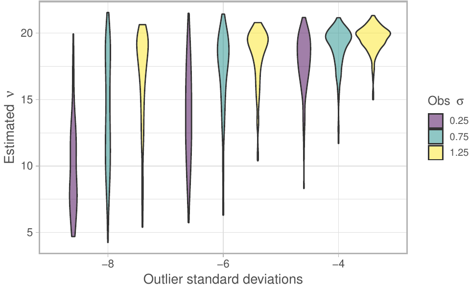

Figure 1: Results for simulated data illustrating support for the Student-t distribution (low values of nu), varying the magnitude of extremes (standard deviations from the mean) and magnitude of observation error.

# Using HMMs to classify regimes in latent DFA trends

An alternative approach to DFA for dimension reduction of multivariate time series data are Hidden Markov Models (HMMs). Like DFA models, they model a latent process for a time series (or collection of multivariate time series). Instead of the latent process being modeled continuously (e.g. as a random walk in DFA), HMMs conceive the latent process as a series of discrete-time, discrete-state first-order Markov chains $s_t \in \left\{ 1, \dots, G \right\}$ with the number of possible states $G$ specified *a priori*. State transition is characterized by the $G\: \times\: G$ transition matrix with simplex rows $\mathbf{A} = \left\{ a_{ig} \right\}$ where $a_{ig} = p({ s }_{ t } = g | { s }_{ t-1 } = i)$ represents the probability of transitioning from state $i$ to $g$. Useful quantities from HMMs include the transition probabilities between latent states, and the probability of being in a given lantent state at each point in time (Zucchini, MacDonald, and Langrock 2017).

HMMs can be applied to raw multivariate data to identify latent states; however, they may also be linked with DFA to identify regimes and transitions in the latent DFA trends. Similar to DFA, applications of HMMs are widely available in R, including via the packages [*depmixS4*](https://CRAN.R-project.org/package=depmixS4) (Visser and Speekenbrink 2010), [*HMM*](https://CRAN.R-project.org/package=HMM) (Himmelmann 2010), and [*msm*](https://CRAN.R-project.org/package=msm) (Jackson 2011). Consistent with our implementation of the Bayesian DFA model, we include fully Bayesian inference in Stan based on (Damiano, Peterson, and Weylandt 2018). We apply independent HMM models to each DFA trend to identify alternate states or regimes. Like with the estimation of DFA models, we use the LOOIC metric to evaluate the relative support for HMMs with different numbers of underlying states, selecting the converged model with the lowest LOOIC. By default, we assume the observation model of the input time series to be normally distributed with the scale parameter equal to the estimated residual variance. However, for some applications, such as datasets with changing sampling frequencies over time, uncertainty in DFA trends may also vary through time. To propogate this uncertainty forward, we also allow the residual variance to be entered as a known quantity for every data point in our `find_regimes()` function.

# Example application: identifying common patterns in sea surface temperatures in the Northeast Pacific Ocean

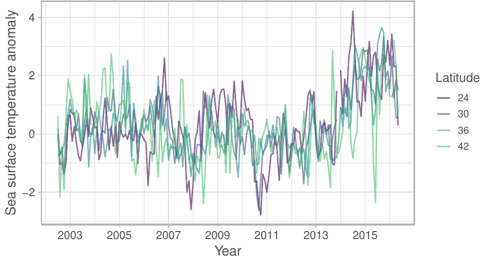

Figure 2: Sea surface temperature anomalies, at four stations on the west coast of the USA ordered by increasing latitude. The station coordinates are (113W, 24N), (119W, 30N), (122W, 36N), (125W, 42N).

Initially, we fit a DFA model with 2 hidden trends, and will assume the 4 time series to have the same error variances $\textbf{R}$. We will fit the DFA model with possible extremes, modeling process error with a Student-t distribution by using the argument `estimate_nu()`. To evaluate whether these data support an extreme DFA with trends modeled as a t-distribution, we will fit two competing forms: one modeling the random walks with a Gaussian distribution, and the other using a Student-t distribution. Generating posterior samples for each model takes approximately 7 minutes per chain, when MCMC chains aren’t run in parallel.

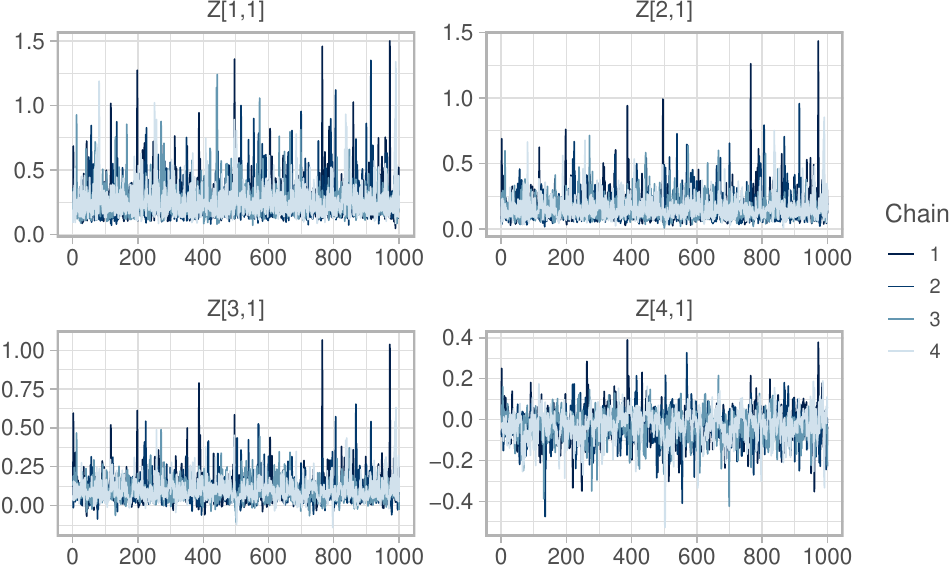

Figure 3: MCMC trace plots of loading parameters (Z) in the DFA model with Student-t errors.

As a consistency diagnostic, we also retrieve the estimated degrees of freedom from the Student-t model $\nu$. By visual inspection, Figure 4 shows that the posterior distribution on $\nu$ is lower than the prior distribution.

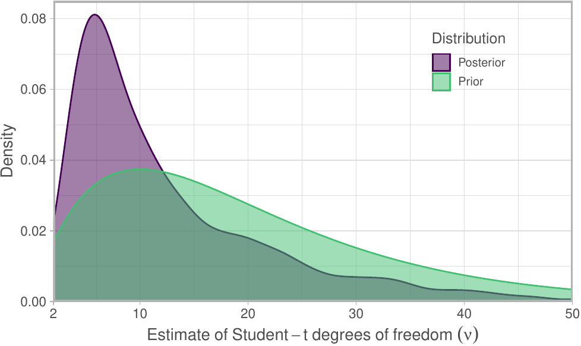

Figure 4: Posterior and prior degrees of freedom in the DFA model with Student-t errors.

## Visualizing the trends and loadings

We will focus the remaining portion of our analysis on the results from the DFA model with Student-t deviations. In Figure 5, we observe that Trend 1 and Trend 2 both support SST anomalies increasing over the latter half of the time series. Both trends appear to have reversed direction (reverting to the mean in the last 2–3 years) and this pattern is more evident in Trend 1. Because we do not model seasonality explicitly, for example by including a covariate effect for the month, each of the estimated trends also includes the within-year variability that describes seasonal patterns in observed sea surface temperature.

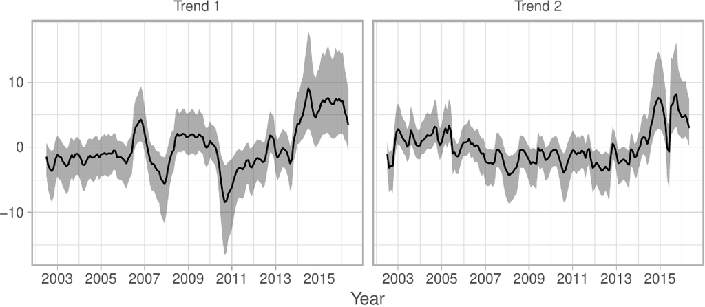

Figure 5: Latent trends from the DFA model with Student-t process deviations. Trends are rotated using the `stats::varimax()` rotation.

In the violin plot of Figure 6, we note that more southern stations (24 and 30N) contribute largely to Trend 1, while the more northern stations appear to load more heavily on Trend 2.

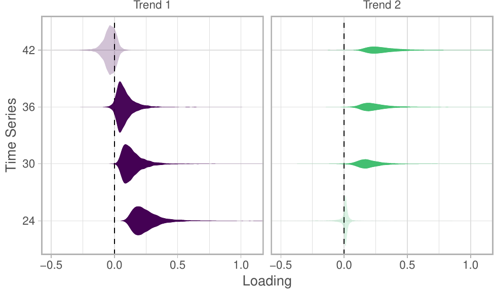

Figure 6: Loadings from the DFA model with Student-t process deviations. Loadings are rotated using the `stats::varimax()` rotation.